# R Notebook

# Resources (https://stackoverflow.com/questions/17031002/get-weekdays-in-english-in-r)

```r
sleepday_v2 <- sleep_day %>% mutate(Date = substring(SleepDay,1,9))
daily_activity_v2 <- daily_activity %>% mutate(Date = daily_activity$ActivityDate)

combined_data_ij <- merge(sleepday_v2, daily_activity_v2, by=c("Id","Date"))
combined_data_oj <- merge(sleepday_v2, daily_activity_v2, by=c("Id","Date"), all=TRUE)
```

```r
sleepday_v2$Date <- as.Date(sleepday_v2$Date, "%m/%d/%Y") #The default format is yyyy-mm-dd
sleepday_v2$month <- format(as.Date(sleepday_v2$SleepDate), "%m")
sleepday_v2$day <- format(as.Date(sleepday_v2$SleepDate), "%d")
sleepday_v2$year <- format(as.Date(sleepday_v2$SleepDate), "%Y")
sleepday_v2$day_of_week <- format(as.Date(sleepday_v2$SleepDate), "%A")
daily_activity_v2$Date <- as.Date(daily_activity_v2$Date,"%m/%d/%Y") #The default format is yyyy-mm-dd
daily_activity_v2$month <- format(as.Date(daily_activity_v2$ActivityDate), "%m")
daily_activity_v2$day <- format(as.Date(daily_activity_v2$ActivityDate), "%d")
daily_activity_v2$year <- format(as.Date(daily_activity_v2$ActivityDate), "%Y")
daily_activity_v2$day_of_week <- format(as.Date(daily_activity_v2$ActivityDate), "%A")
```

# create breaks

#breaks <- hour(hm(“00:00”, “6:00”, “12:00”, “18:00”, “23:59”)) # labels for the breaks #labels <- c(“Night”, “Morning”, “Afternoon”, “Evening”) ### Leavint the codes for learning purposes, using lubridate as library. Note: Data must be a date time column of course.

### Merging, we have two data sets, IJ uses an inner join, keeping only rows matched in the two datasets. OJ sticks to the outer join concept, kepping all values and joining them if posible, I decided this approach as a complete view but having the leaking data of missing dates.

```r
combined_data_ij <- merge(sleepday_v2, daily_activity_v2, by=c("Id","Date","month","day","year","day_of_week"))
combined_data_oj <- merge(sleepday_v2, daily_activity_v2, by=c("Id","Date","month","day","year","day_of_week"), all=TRUE)
```

### Grouping data into a new data frame to analyze.

```r
df <- combined_data_oj %>%
  mutate(weekday = wday(SleepDate, label = TRUE)) %>%  #creates weekday field using wday()
  group_by(weekday) %>%  #groups by usertype and weekday
  summarise(Observations = n()                          #calculates the number of rides and average duration
  ,average_sleep_duration = mean(TotalTimeInBed), average_steps = mean(TotalSteps), average_distance = mean(TotalDistance)) %>%         # calculates the average duration
  arrange(weekday)                              # sorts
df
```

[output not shown]

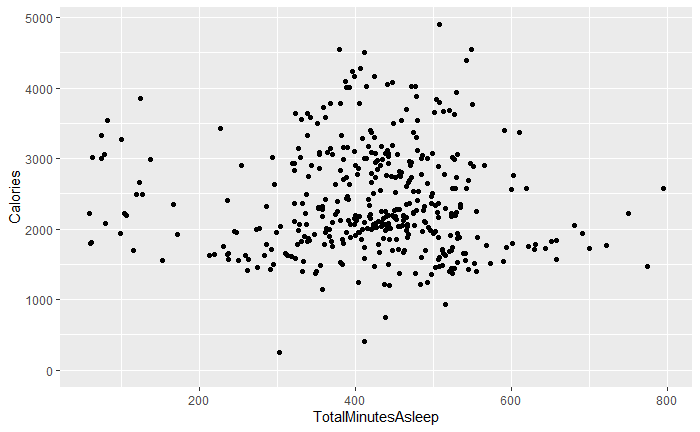

```r
ggplot(data=combined_data_oj, aes(x=TotalMinutesAsleep, y=Calories)) + geom_point()
```

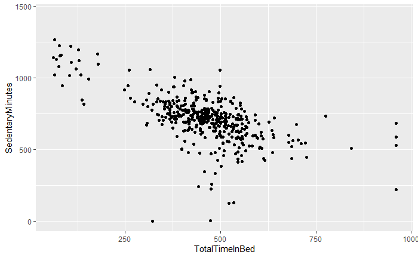

```r
ggplot(data=combined_data_oj, aes(x=TotalTimeInBed, y=SedentaryMinutes)) + geom_point()
```